# 공분산(Covariance)과 상관계수(Correlation Coeffcient)

| 상태 | 1 | 2 | 3 | 4 | 5 |
| --- | --- | --- | --- | --- | --- |
| 확률 | 0.10 | 0.15 | 0.25 | 0.35 | 0.15 |
| 수익률A | -0.40 | -0.10 | 0.20 | 0.50 | 0.80 |
| 수익률B | -0.15 | -0.05 | 0.20 | 0.25 | 0.15 |

위의 표를 데이터로 구조화하면,

```r
# Sys.setlocale(category = "LC_CTYPE", locale = "ko_KR.UTF-8")
example1 <- data.frame(n = 1:5,
            probability = c(0.10, 0.15, 0.25, 0.35, 0.15),
            return_rate_a = c(-0.40, -0.10, 0.20, 0.50, 0.80),
            return_rate_b = c(-0.15, -0.05, 0.20, 0.25, 0.15))
example1
```

| n | probability | return_rate_a | return_rate_b |
| --- | --- | --- | --- |
| 1 | 0.10 | -0.4 | -0.15 |
| 2 | 0.15 | -0.1 | -0.05 |
| 3 | 0.25 | 0.2 | 0.20 |
| 4 | 0.35 | 0.5 | 0.25 |
| 5 | 0.15 | 0.8 | 0.15 |

주식 A 와 B에 대하여 예상되는 기대수익률(Expected rate of return)은 각각 아래와 같다.

```r
expected_rate_a <- sum(example1$probability * example1$return_rate_a)
expected_rate_b <- sum(example1$probability * example1$return_rate_b)
print(paste0("A - Expected rate = ", expected_rate_a, ", B - Expected rate = ", expected_rate_b))
```

```
[1] "A - Expected rate = 0.29, B - Expected rate = 0.1375"
```

두 주식의 표준편차(Standard deviation)는 각각 아래와 같다.

1. 기대수익률을 중심으로 편차를 구하여 제곱한다.
2. 편차의 제곱에 각 편차가 실현될 확률을 곱한다.
3. 모든 상황에 대하여 합을 구하고 제곱근을 구한다.

```r
sd_a <- sqrt(sum(example1$probability * (example1$return_rate_a - expected_rate_a)^2))
sd_b <- sqrt(sum(example1$probability * (example1$return_rate_b - expected_rate_b)^2))
print(paste0("A - sd = ", sd_a, ", B - sd = ", sd_b))
```

```
[1] "A - sd = 0.356230262611137, B - sd = 0.137727085208393"
```

- 공분산 > 0 이면, 두 확률변수가 비례적인 관계.
- 공분산이 0 에 가까우면, 관련성이 없음.
- 공분산 < 0 이면, 두 확률변수가 반비례 관계.

단점은 공분산은 측정단위의 영향을 받기 때문에, 공분산이 크다고해서 두 확률변수간 연관성이 높은 것은 아님. (그래서 상대적 척도로 바꾼 상관계수를 산출한다.)

```r
data.frame(calculrate = paste0(example1$probability, " (", example1$return_rate_a, -expected_rate_a, ") (",
                               example1$return_rate_b, -expected_rate_b, ")"))
```

| calculrate |
| --- |
| 0.1 (-0.4-0.29) (-0.15-0.1375) |
| 0.15 (-0.1-0.29) (-0.05-0.1375) |
| 0.25 (0.2-0.29) (0.2-0.1375) |
| 0.35 (0.5-0.29) (0.25-0.1375) |
| 0.15 (0.8-0.29) (0.15-0.1375) |

```r
cov_ab <- sum(example1$probability * (example1$return_rate_a - expected_rate_a) * (example1$return_rate_b - expected_rate_b))
```

상관계수는 공분산을 두 확률변수의 표준편차의 곱으로 나눈 값이며, 공분산을 상대적 척도로 변환한 값이라고 생각하면 된다. 항상 1 과 -1 사이의 값을 갖는다.

- 상관계수 = 1, 완벽한 비례적인 관계(1차함수의 직선의 관계)
- 0 < 상관계수 < 1, 두 확률변수는 비례적인 관계
- 상관계수 = 0, 아무런 관련없이 독립적인 변동관계
- -1 < 상관계수 < 0, 두 확률변수는 반비례적인 관계
- 상관계수 = -1, 완벽한 반비례적인 관계(1차함수의 직선의 관계)

주식 a 와 B사이의 상관계수는 다음과 같이 계산된다.

```r
cov_ab / (sd_a * sd_b)
```

```
[1] 0.7872603
```

언제나 1과 -1 사이의 값을 가지며, 수익률이 완전히 비례적인 관계일때 1, 완전히 반비례관계를 갖고 변동하는 경우 -1 이다. 두 확률변수가 밀접한 비례관계일수록 1에 가깝고, 밀접한 반비례 관계일수록 -1 에 가깝다.  
실무적으로 관측자료를 통하여, 공분산(Covariance)은 아래식으로구함.

$$Cov(R_{i},R_{j}) = \frac{1}{T-1}\{(R_{i1}-\bar{R})(R_{j1}-\bar{R})+(R_{i2}-\bar{R})(R_{j2}-\bar{R})+\cdots+(R_{iT}-\bar{R})(R_{jT}-\bar{R}) \}$$

| 월 | A주식 수익률 | B주식 수익률 |
| --- | --- | --- |
| 2007.07 | 0.2238 | 0.0000 |
| 2007.08 | -0.0456 | -0.0545 |
| 2007.09 | 0.0956 | -0.0128 |
| 2007.10 | -0.0131 | -0.0389 |
| 2007.11 | -0.0442 | -0.0337 |
| 2007.12 | -0.0509 | 0.0279 |
| 2008.01 | 0.0487 | 0.3244 |
| 2008.02 | -0.1534 | 0.0169 |
| 2008.03 | -0.1208 | 0.1944 |
| 2008.04 | 0.0875 | -0.0697 |

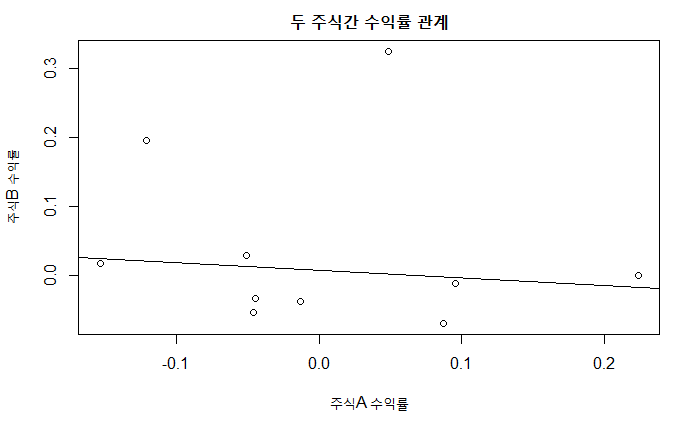

| 구분 | 주식A | 주식B |
| --- | --- | --- |
| 평균수익률 | $\bar{R}_A=0.00276$ | $\bar{R}_B=0.0354$ |
| 표준편차 | $S_A=0.1125942$ | $S_B=0.1256981$ |

공분산 -0.0017237  
상관계수 -0.1217886